# Projekt - faza II

Mateusz Bąkała & Dominik ®afacz

12 czerwca 2019

# W poprzednim sezonie…

- …anonimowi osobnicy usunęli powtarzające się członki zbioru danych. Jednoręki, jednonogi, jednooki dataset został potem zrównany z przedziałem jednostkowym.
- …bohaterowie zdobyli swoje pierwsze, białe pasy w porównywaniu rozkładów.
- …tysiące modeli i dziesiątki datasetów starło się na śmierć i życie w walce o finałową rozgrywkę.
- …krwawą jatkę w finale urządził `ranger`, nie dając innym modelom szans na przetrwanie.
- …ostateczny trening `rangera` z sensei pozostawił jednak niedosyt – mistrz nie zwyciężył na międzygalaktycznej arenie.

# Co nowego w tym sezonie?

## Plejada nowych, młodych gwiazd!

Setki datasetów i modeli, które pokochały miliony! (Zwłaszcza że trzeba było kimś zastąpić poległych z poprzedniego sezonu.) Tym razem casting został przeprowadzony na niespotykaną wcześniej skalę, ściągając tysiące datasetów z całego świata, by ostatecznie zrekrutować grono wybrańców.

Wsłuchując się w głosy widzów poprzedniego sezonu, tym razem scenarzyści nie będą mieli litości dla mało ambitnych modeli. To oznacza WIĘCEJ czasu ekranowego dla tych modeli, których perypetiami widzowie żyją najbardziej! Nie będzie jednak taryfy ulgowej dla mistrza poprzedniego sezonu – każdy model zaczyna z czystą kartą.

## Rozwinięcie wątków z poprzedniego sezonu

Jednym z największych problemów Naszych Bohaterów było porównywanie rozkładów. Czy uda im się z tym poradzić w nowych odcinkach?

**Spoiler alert!** I tak i nie.

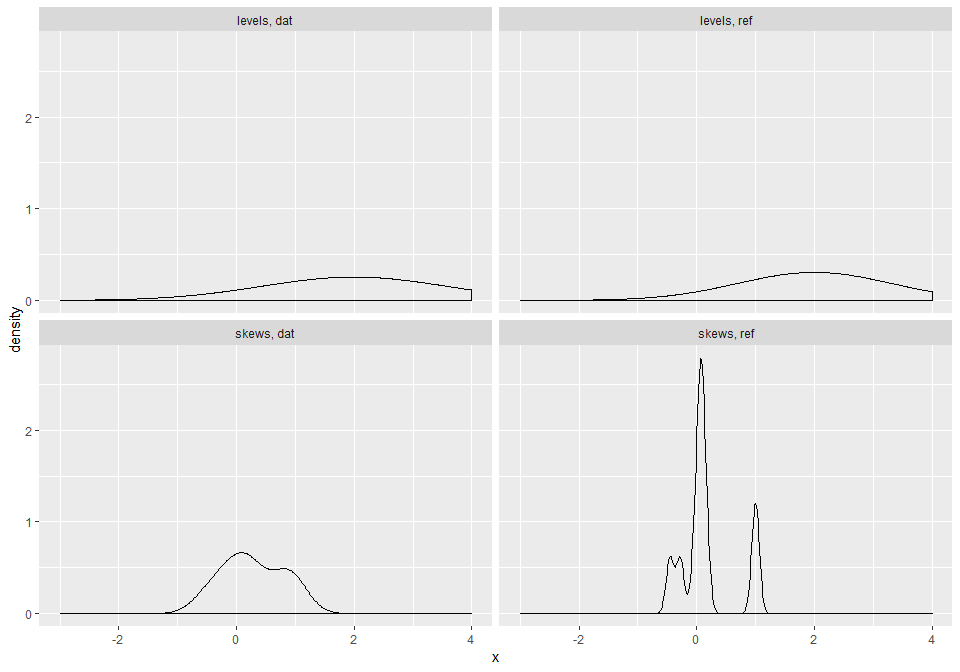

Cały szereg nowych szeregów i całek!

- dywergencja Kullbacka-Leiblera

$$D_{\text{KL}}(P\parallel Q)=\int _{-\infty }^{\infty }p(x)\log \left({\frac {p(x)}{q(x)}}\right)\,dx$$

- odległość Hellingera

$$H^2(P,Q)=\frac{1}{2}\int \left( {\sqrt{\frac{dP}{d\lambda}}-\sqrt{\frac{dQ}{d\lambda}}}\right)^2d\lambda$$

- odległość całkowitej wariancji

$$\delta(P,Q) = \sup_{A\in \mathcal{F}} |P(A)-Q(A)|$$

- odległość Kołmogorowa-Smirnowa

$$D_n(P,Q) = \sup_{x\in\mathcal{F}}|F_P(x)-F_Q(x)|$$

- odległość Wassersteina

$$W_p(P,Q) = \left( \int_0^1 |P^{-1}(u)-Q^{-1}(u)|^p du \right)^{1/p},$$
Dla przykładowych danych:

|  | KLD | Hellinger | TV | Kolmogorov | Wasserstein |
| --- | --- | --- | --- | --- | --- |
| levels | 0.0045526 | 1 | 0.0000000 | 0.0000000 | 0.0000000 |
| skews | 2.7133220 | 1 | 0.9166667 | 0.3666667 | 0.1698288 |

Po wielu perypetiach i zwrotach akcji, udało się porównać rozkłady. Ale ocena nie jest jednoznaczna. Co jeśli factory mają całkiem podobne rozkłady, a numeryki nie? Bohaterowie i widzowie zachodzą w głowę. I wiadomo, że rozwiązania z happy endem zapewne nie będzie. Ale może choć złoty środek? Albo średnia?

|  | KLD | Hellinger | TV | Kolmogorov | Wasserstein |
| --- | --- | --- | --- | --- | --- |
| means | 0.2009105 | 1.033297 | 0.2009105 | 1.0332968 | 0.2009105 |
| sqmeans | 0.1111428 | 1.000000 | 0.0000000 | 0.0000000 | 0.0000000 |
| max | 2.7133220 | 1.000000 | 0.9166667 | 0.3666667 | 0.1698288 |

Okazało się, że problemów w połowie sezonu jest więcej niż było. Jak wybrać tego jedynego/tę jedyną. A może nie trzeba wybierać?

Uśrednione metryki jednak nas nie znajdują. Potrzebujemy miary podobieństwa, a więc niejako “odwrotności” metryki. Jednak trzeba uważać, z jaką metryką się zadajemy, bo nie wszystkie zareagują tak samo na nasze czułe słówka.

Scenarzyści mają kłopoty.

|  | KLD | Hellinger | TV | Kolmogorov | Wasserstein |
| --- | --- | --- | --- | --- | --- |
| means | 0.8179856 | 0.0011087 | 0.6385440 | 0.0011087 | 0.8179856 |
| sqmeans | 0.8948109 | 0.0000000 | 1.0000000 | 1.0000000 | 1.0000000 |
| max | 0.0663161 | 0.0000000 | 0.0069444 | 0.4011111 | 0.8438093 |

Uff.

Teraz to samo dla pozostałych kilkuset datasetów.

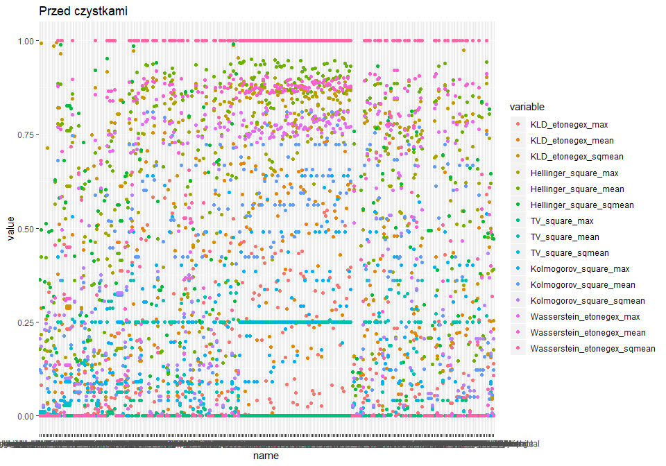

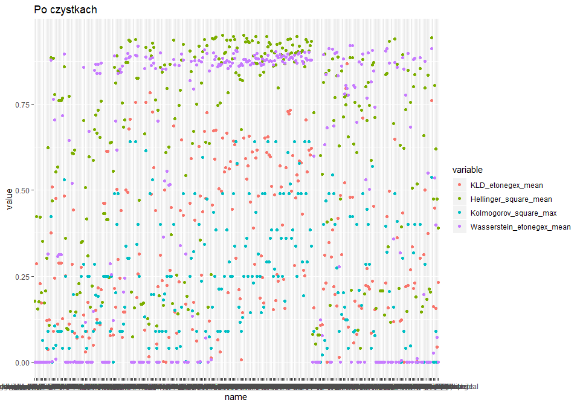

## ELO dla każdego

Po poprzednim sezonie fani narzekali na za mało ELO w ELO. Teraz będzie więc jeszcze więcej - liczymy dla każdej z wcześniejszych metryk! A potem porównujemy wyniki. Kto będzie najpopularniejszym wyborem fanów?

| X | KLD | Hellinger | Kolmogorov | Wasserstein |
| --- | --- | --- | --- | --- |
| classif.C50 | 1 | 48 | 34 | 48 |
| classif.cforest | 20 | 2 | 6 | 50 |
| classif.glmnet | 37 | 34 | 21 | 47 |
| classif.h2o.deeplearning | 6 | 52 | 12 | 52 |
| classif.mda | 35 | 12 | 26 | 49 |
| classif.plr | 44 | 51 | 49 | 51 |
| classif.plsdaCaret | 51 | 15 | 43 | 53 |

## Niech żyje zbrodniczy reżim! Niech żyje, skoro demokracja i tak nie działa.

Teraz następuje punkt, w którym trzeba wybrać któreś z tych datasetów i któreś z tych modeli. Skoro zaś mamy metryk więcej aniżeli w poprzednich sezonach, trzeba w pewnym stopniu to zautomatyzować. Na stażystach nie można polegać – można natomiast zdecydować się na *plot twist* i pozwolić metrykom głosować.

Z **MD3** wiemy (przynajmniej niektórzy), że nie ma czegoś takiego jak “obiektywnie najlepszy system głosowania”, toteż możemy wybrać tych systemów kilka i zobaczyć, co z tego wyjdzie.

No i wyszedł **glmnet**, wybrany niemal jednogłośnie przez głosowania (które ostatecznie jednak i my musieliśmy rozstrzygnąć – to był element *deus ex machina*)

W analogiczny sposób wybraliśmy *ileś* najlepszych datasetów. Tym razem uwzględniliśmy głosy wszystkich.

Na tych datasetów wytrenowaliśmy nasz model, korzystając z optymizacji opratej na modelu (MBO). Ostatecznie wybraliśmy zestaw parametrów.

Jaki będzie wynik?

Dowiecie się w dzisiejszym, ostatnim odcinku.

(to jest tak zwany cliffhanger)